# Ilustración problemas de agrupamiento

Juan David Ospina Arango

4/8/2021

## Ejemplo 1: datos simulados

Simularemos un conjunto de datos con variables numéricas y categóricas binarias:

```r
N <- 200
set.seed(20210408)
x1 <- rnorm(N,mean=100,sd=15)
x2 <- runif(N,28,40)
x3 <- rpois(N, lambda = 8)
c1 <- rbinom(N,size=1,prob=0.2)
c2 <- rbinom(N,size=1, prob=0.6)
c3 <- rbinom(N, size=1,prob=0.01)
datos <- data.frame(x1,x2,x3,c1,c2,c3)
```

Veamos una descripción de los datos con el comando `summary()`:

```r
summary(datos)
```

```
##        x1               x2              x3               c1
##  Min.   : 66.22   Min.   :28.02   Min.   : 1.000   Min.   :0.00
##  1st Qu.: 88.01   1st Qu.:31.13   1st Qu.: 6.000   1st Qu.:0.00
##  Median : 98.82   Median :34.29   Median : 8.000   Median :0.00
##  Mean   : 99.77   Mean   :34.14   Mean   : 8.085   Mean   :0.21
##  3rd Qu.:110.95   3rd Qu.:37.18   3rd Qu.:10.000   3rd Qu.:0.00
##  Max.   :139.77   Max.   :39.97   Max.   :17.000   Max.   :1.00
##        c2              c3
##  Min.   :0.000   Min.   :0.000
##  1st Qu.:0.000   1st Qu.:0.000
##  Median :1.000   Median :0.000
##  Mean   :0.615   Mean   :0.015
##  3rd Qu.:1.000   3rd Qu.:0.000
##  Max.   :1.000   Max.   :1.000
```

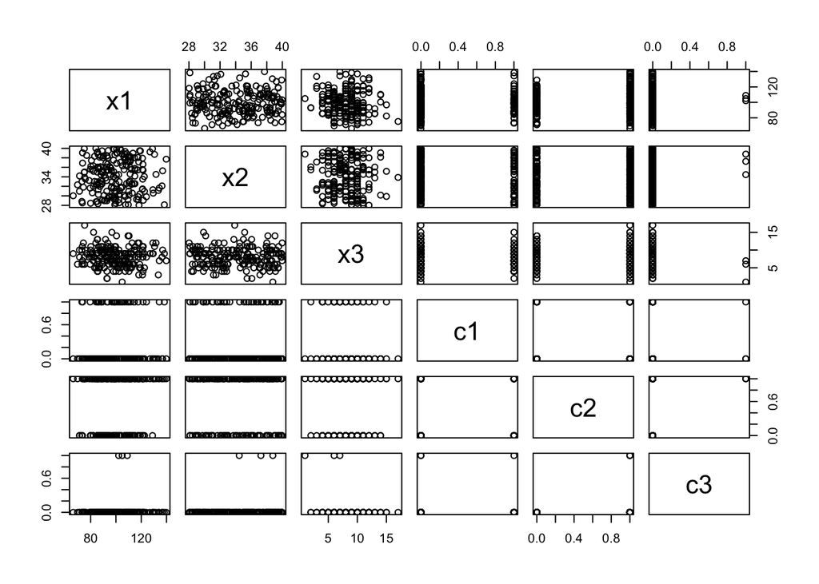

```r
pairs(datos)
```

Hagamos un `pairs()` de solo las variables numéricas (no binarias):

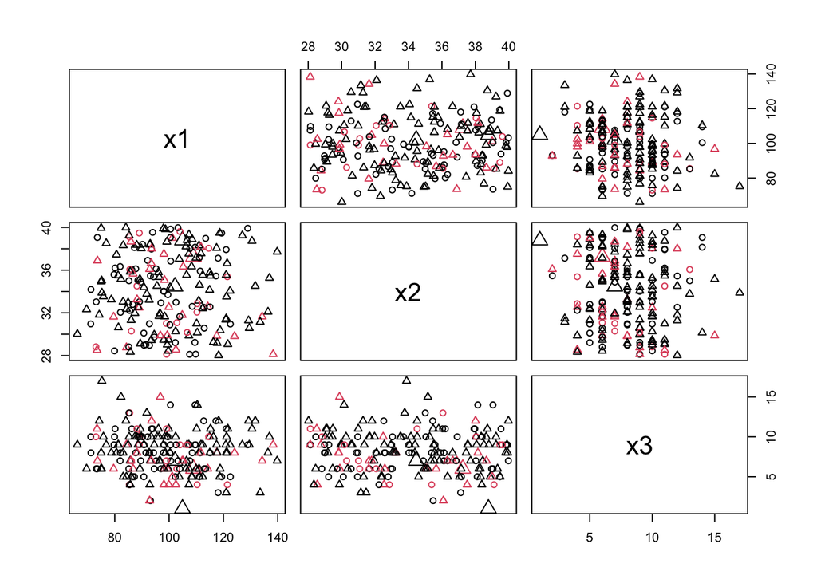

```r
pairs(datos[,c("x1","x2","x3")],col=datos$c1+1,pch=datos$c2+1,cex=datos$c3+1)
```

Comenzaremos usando el agrupamiento jerárquico. Para lo cual calcularmos la matriz de distancia correspondiente para cada tipo de variable.

Primero se separa el conjunto de dato en dos: un conjunto con solo las variables binarias y otro con las otras variables numéricas:

```r
datos_cat <- datos[,c("c1","c2","c3")]
datos_num <- datos[,c("x1","x2","x3")]
```

Ahora se normaliza el conjunto que tiene las variables numéricas:

```r
datos_num_scaled <- scale(datos_num,center = TRUE, scale = TRUE)
```

Ahora se calculan las distancias entre los individuos en cada conjunto de datos:

```r
D_cat <- dist(datos_cat,method="binary",diag=TRUE)
D_num <- dist(datos_num_scaled,diag=TRUE)
```

Distancias según las variables binarias:

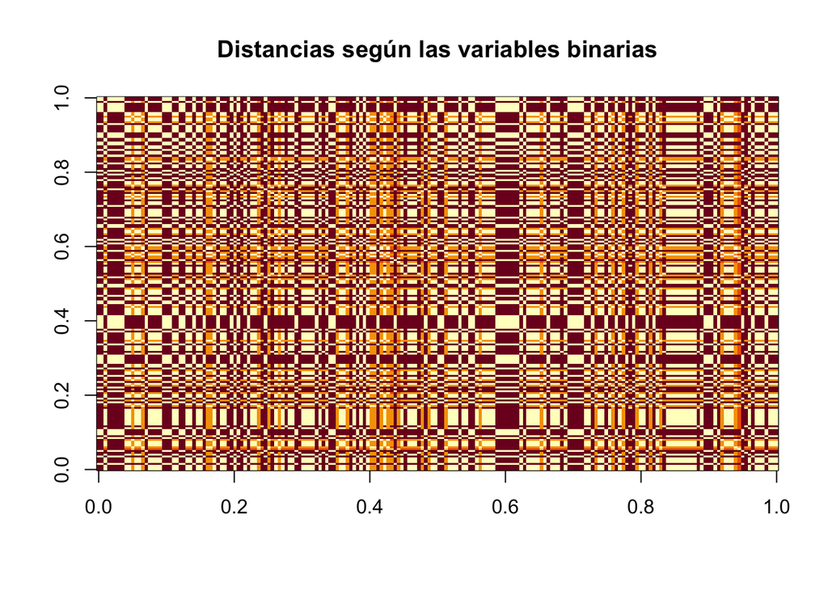

```r
# Tarea: poner una barra de colores
image(t(as.matrix(D_cat)[,N:1]), main="Distancias según las variables binarias")
```

Distancias según las variables numéricas (diferentes de binarias):

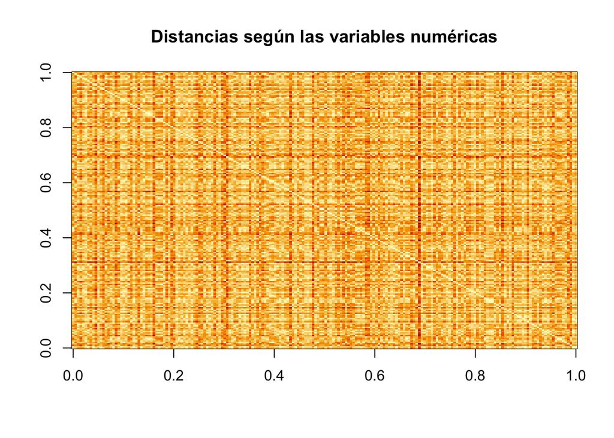

```r
# Tarea: poner una barra de colores
image(t(as.matrix(D_num)[,N:1]), main="Distancias según las variables numéricas")
```

Estamos en un espacio de dimensión $p=p_1+p_2$, si $x_1=[{x_1^{1} }^T\quad {x_1^{2}}^T]^T$ y $x_2=[{x_2^{1} }^T\quad {x_2^{2}}^T]^T$, con $x_1^{1}, x_2^{1} \in \mathbb{R}^{p_1}$ y $x_1^{2}, x_2^{2} \in \mathbb{R}^{p_2}$ y $d_1$ y $d_2$ son funciones de distancia, entonces se puede definir $d_{Tot}(x_1, x_2)=d_1(x_1^{1},x_2^{1})+d_2(x_1^{2},x_2^{2})$.

Ahora sumemos las dos matrices de distancias:

```r
D_Tot <- D_cat + D_num
```

Visualicemos la matriz de distancias total:

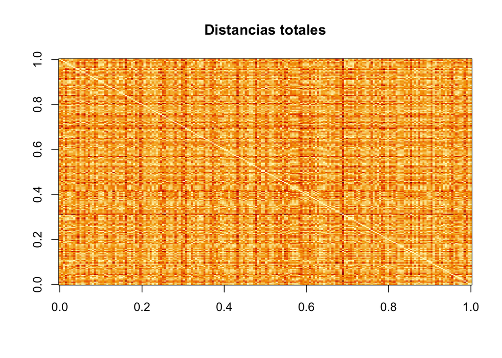

```r
image(t(as.matrix(D_Tot)[,N:1]), main="Distancias totales")
```

Ahora hagamos el agrupamiento jerárquico:

```r
cluster_jerar <- hclust(D_Tot,method = "complete")
```

Visualicemos el dendograma:

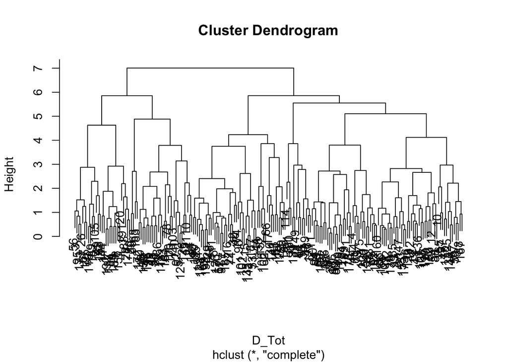

```r
plot(cluster_jerar)
```

De acuerdo a este gráfico se identifican cinco grupos potencialmente interesantes:

```r
etiqueta_grupo <- cutree(cluster_jerar,k=5)
```

Veamos cuántos elementos tiene cada grupo:

```r
table(etiqueta_grupo)
```

```
## etiqueta_grupo
##  1  2  3  4  5
## 29 78 32 48 13
```

Veamos ahora las características de cada grupo:

Grupo 1:

```r
summary(datos[etiqueta_grupo==1,])
```

```
##        x1              x2              x3               c1
##  Min.   :110.1   Min.   :28.02   Min.   : 6.000   Min.   :0.0000
##  1st Qu.:117.5   1st Qu.:30.37   1st Qu.: 8.000   1st Qu.:0.0000
##  Median :121.3   Median :33.51   Median : 9.000   Median :0.0000
##  Mean   :123.7   Mean   :33.30   Mean   : 9.241   Mean   :0.1379
##  3rd Qu.:129.5   3rd Qu.:35.54   3rd Qu.:10.000   3rd Qu.:0.0000
##  Max.   :139.8   Max.   :39.92   Max.   :12.000   Max.   :1.0000
##        c2               c3
##  Min.   :0.0000   Min.   :0
##  1st Qu.:1.0000   1st Qu.:0
##  Median :1.0000   Median :0
##  Mean   :0.9655   Mean   :0
##  3rd Qu.:1.0000   3rd Qu.:0
##  Max.   :1.0000   Max.   :0
```

Grupo 2:

```r
summary(datos[etiqueta_grupo==2,])
```

```
##        x1               x2              x3               c1
##  Min.   : 73.58   Min.   :28.12   Min.   : 3.000   Min.   :0.000
##  1st Qu.: 90.94   1st Qu.:32.65   1st Qu.: 5.250   1st Qu.:0.000
##  Median :100.30   Median :36.33   Median : 7.000   Median :0.000
##  Mean   : 99.28   Mean   :35.41   Mean   : 6.718   Mean   :0.141
##  3rd Qu.:108.50   3rd Qu.:38.31   3rd Qu.: 8.000   3rd Qu.:0.000
##  Max.   :122.55   Max.   :39.97   Max.   :10.000   Max.   :1.000
##        c2               c3
##  Min.   :0.0000   Min.   :0.00000
##  1st Qu.:0.0000   1st Qu.:0.00000
##  Median :1.0000   Median :0.00000
##  Mean   :0.5256   Mean   :0.02564
##  3rd Qu.:1.0000   3rd Qu.:0.00000
##  Max.   :1.0000   Max.   :1.00000
```

Grupo 3:

```r
summary(datos[etiqueta_grupo==3,])
```

```
##        x1               x2              x3              c1
##  Min.   : 75.26   Min.   :29.87   Min.   : 8.00   Min.   :0.0000
##  1st Qu.: 87.65   1st Qu.:34.02   1st Qu.:10.00   1st Qu.:0.0000
##  Median : 92.81   Median :36.13   Median :11.00   Median :0.0000
##  Mean   : 95.16   Mean   :36.13   Mean   :11.34   Mean   :0.2188
##  3rd Qu.:100.98   3rd Qu.:38.19   3rd Qu.:12.25   3rd Qu.:0.0000
##  Max.   :121.00   Max.   :39.97   Max.   :17.00   Max.   :1.0000
##        c2               c3
##  Min.   :0.0000   Min.   :0
##  1st Qu.:0.0000   1st Qu.:0
##  Median :0.0000   Median :0
##  Mean   :0.2812   Mean   :0
##  3rd Qu.:1.0000   3rd Qu.:0
##  Max.   :1.0000   Max.   :0
```

Grupo 4:

```r
summary(datos[etiqueta_grupo==4,])
```

```
##        x1               x2              x3               c1
##  Min.   : 66.22   Min.   :28.13   Min.   : 4.000   Min.   :0.0000
##  1st Qu.: 79.37   1st Qu.:29.77   1st Qu.: 6.750   1st Qu.:0.0000
##  Median : 86.07   Median :31.64   Median : 9.000   Median :0.0000
##  Mean   : 86.85   Mean   :31.56   Mean   : 8.542   Mean   :0.2292
##  3rd Qu.: 96.13   3rd Qu.:33.08   3rd Qu.:10.000   3rd Qu.:0.0000
##  Max.   :107.29   Max.   :35.80   Max.   :13.000   Max.   :1.0000
##        c2             c3
##  Min.   :0.00   Min.   :0
##  1st Qu.:0.75   1st Qu.:0
##  Median :1.00   Median :0
##  Mean   :0.75   Mean   :0
##  3rd Qu.:1.00   3rd Qu.:0
##  Max.   :1.00   Max.   :0
```

Grupo 5:

```r
summary(datos[etiqueta_grupo==5,])
```

```
##        x1               x2              x3          c1               c2
##  Min.   : 92.83   Min.   :28.54   Min.   :1   Min.   :0.0000   Min.   :0.0000
##  1st Qu.: 99.89   1st Qu.:31.47   1st Qu.:3   1st Qu.:0.0000   1st Qu.:0.0000
##  Median :104.91   Median :32.54   Median :4   Median :1.0000   Median :1.0000
##  Mean   :108.32   Mean   :32.97   Mean   :4   Mean   :0.6923   Mean   :0.6923
##  3rd Qu.:114.25   3rd Qu.:35.38   3rd Qu.:6   3rd Qu.:1.0000   3rd Qu.:1.0000
##  Max.   :133.52   Max.   :38.78   Max.   :7   Max.   :1.0000   Max.   :1.0000
##        c3
##  Min.   :0.00000
##  1st Qu.:0.00000
##  Median :0.00000
##  Mean   :0.07692
##  3rd Qu.:0.00000
##  Max.   :1.00000
```

```r
aggregate(datos_num$x1~etiqueta_grupo,FUN=sd)
```

```
##   etiqueta_grupo datos_num$x1
## 1              1     8.286647
## 2              2    11.565306
## 3              3    11.416202
## 4              4    10.737565
## 5              5    11.874788
```

Fin.